# TSdist

haoyi.li

2018年11月15日

# 1 ACFDistance

ACF：autocorrelation coefficients

## 1.1 描述

根据估计的自相关系数计算两个数值时间序列之间的差异性。

## 1.2 用法

```
ACFDistance(x, y, ...)
```

## 1.3 参数说明

```
x：第一个数值时间序列
y：第二个数值时间序列
...：其他附加参数
```

## 1.4 示例

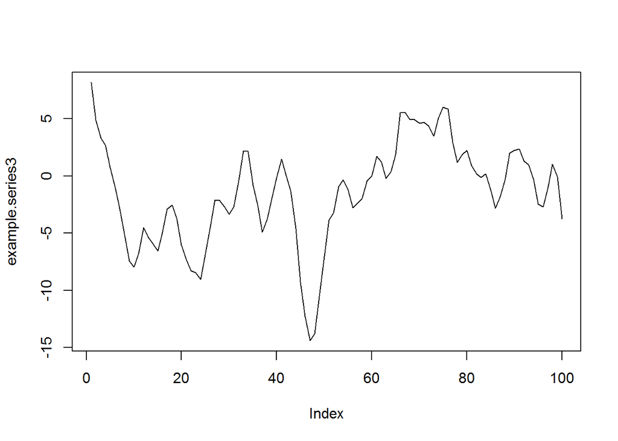

```r
# TSdist包自带的对象example.series3和example.series4，是长度分别为100,120的两个数值时间序列
data(example.series3)
data(example.series4)
plot(example.series3, type = 'l')
```

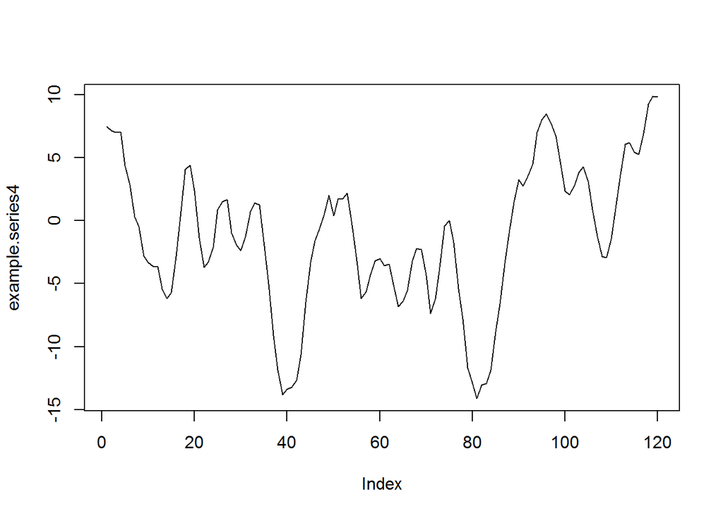

```r
plot(example.series4, type = 'l')
```

```r
# 查看时间序列对象的信息：
# help(example.series)

# 使用默认参数计算两个时间序列的ACFDistance:
ACFDistance(example.series3, example.series4)
```

```
## [1] 1.702706
```

# 2 ARLPCCepsDistance

## 2.1 描述

Computes the dissimilarity between two numeric time series in terms of their Predictive Coding (LPC) ARIMA processes. 根据线性预测编码(LPC)ARIMA过程计算两个数值时间序列之间的差异性。

## 2.2 用法

```
ARLPCCepsDistance(x, y, ...)
```

## 2.3 参数说明

```
x：第一个数值时间序列
y：第二个数值时间序列
...：其他附加参数
```

## 2.4 示例

```r
# 使用默认参数，计算两个时间序列之间的ar.lpc.ceps距离。在这种情况下，自动为每个系列选择一个AR模型
ARLPCCepsDistance(example.series3, example.series4)
```

```
## [1] 0.2722122
```

```r
# 计算两个序列之间的ar.lpc.cep距离，并在附加参数中给出每个序列的ARIMA模型的阶数
ARLPCCepsDistance(example.series3, example.series4, order.x=c(3,0,2),
order.y=c(3,0,2))
```

```
## [1] 0.2836115
```

# 3 ARMahDistance

Maharaj提出的基于模型的差异性

## 3.1 描述

计算Maharaj提出的基于模型的差异性

## 3.2 用法

```
ARMahDistance(x, y, ...)
```

## 3.3 参数说明

```
x：第一个数值时间序列
y：第二个数值时间序列
...：其他附加参数
```

## 3.4 返回值说明

```
statistic: 均匀性检验的统计量
p-value: 均匀性检验得出的p值。
```

## 3.5 示例

```r
# 使用默认参数计算两个时间序列之间的ar.mah距离
ARMahDistance(example.series3, example.series4)
```

```
## $statistic
##          [,1]
## [1,] 0.359041
##
## $p_value
##           [,1]
## [1,] 0.9856909
```

# 4 ARPicDistance

Piccolo(1990)提出的基于模型的差异性

## 4.1 描述

计算Piccolo提出的基于模型的差异性

## 4.2 用法

```
ARPicDistance(x, y, ...)
```

## 4.3 参数说明

```
x：第一个数值时间序列
y：第二个数值时间序列
...：其他附加参数
```

## 4.4 示例

```r
# 使用默认参数，计算两个时间序列之间的picolo距离。在这种情况下，自动为每个系列选择一个AR模型
ARPicDistance(example.series3, example.series4)
```

```
## [1] 0.4062474
```

```r
# 计算两个序列之间的Picolo距离，并在附加参数中给出每个序列的ARIMA模型的阶数
ARPicDistance(example.series3, example.series4, order.x=c(3,0,2),
order.y=c(3,0,2))
```

```
## [1] 0.393323
```

# 5 CCorDistance

Cross-correlation based distance.基于交叉相关（互相关）的距离

## 5.1 描述

计算两个时间序列之间的基于交叉相关（互相关）的距离

## 5.2 用法

```
CCorDistance(x, y, lag.max=(min(length(x), length(y))-1))
```

## 5.3 参数说明

```
x：第一个数值时间序列
y：第二个数值时间序列
lag.max：正整数，定义最大的延迟期数，默认值default=min(length(x), length(y))-1
```

## 5.4 示例

```r
# 计算基于cross-correlation的距离
# 使用默认的lag.max：
CCorDistance(example.series3, example.series4)
```

```
## [1] 0.5350273
```

```r
# 设置lag.max=50：
CCorDistance(example.series3, example.series4, lag.max=50)
```

```
## [1] 0.6091556
```

# 6 CDMDistance

Compression-based Dissimilarity measure 基于压缩的差异性度量

## 6.1 描述

Computes the dissimilarity between two numeric series based on their size after compression 计算两个时间序列之间的基于压缩的差异性

## 6.2 用法

```
CDMDistance(x, y, ...)
```

## 6.3 参数说明

```
x：第一个数值时间序列
y：第二个数值时间序列
...：其他附加参数
```

## 6.4 示例

```r
# 使用默认参数计算
CDMDistance(example.series3, example.series4)
```

```
## [1] 0.9586957
```

# 7 CIDDistance

Complexity-Invariant Distance Measure For Time Series 时间序列的复杂度不变距离度量

## 7.1 描述

基于复杂度估计的欧氏距离修正，计算两个等长的时间序列的差异性

## 7.2 用法

```
CIDDistance(x, y)
```

## 7.3 参数说明

```
x：第一个数值时间序列
y：第二个数值时间序列
```

## 7.4 示例

```r
CIDDistance(example.series1, example.series2)
```

[output not shown]

[output not shown]

# 8 CorDistance

基于Pearson相关性的差异性

## 8.1 描述

Computes two different distance measure based on Pearson’s correlation between a pair of numeric time series of the same length. 计算两个等长时间序列的pearson相关性距离

## 8.2 用法

```
CorDistance(x, y, ...)
```

## 8.3 参数说明

```
x：第一个数值时间序列
y：第二个数值时间序列
...：其他附加参数
```

## 8.4 示例

```r
data(example.series1)
data(example.series2)
# Calculate the first correlation based distance between the series.
CorDistance(example.series1, example.series2)
```

```
## [1] 1.399347
```

```r
# Calculate the second correlation based distance between the series
# by specifying \eqn{beta}.
CorDistance(example.series1, example.series2, beta=2)
```

```
## [1] 0.9590289
```

# 9 CortDistance

Dissimilarity Index Combining Temporal Correlation and Raw Value Behaviors 时间相关性与原始数值行为相结合的不同指标

## 9.1 描述

Computes the dissimilarity between two numeric series of the same length by combining the dissimilarity between the raw values and the dissimilarity between the temporal correlation behavior of the series. 计算两个等长时间序列的差异性，通过合并原始数据之间的差异性和序列的时间相关行为的差异性

## 9.2 用法

```
CortDistance(x, y, ...)
```

## 9.3 参数说明

```
x：第一个数值时间序列
y：第二个数值时间序列
...：其他附加参数
```

## 9.4 示例

```r
# Calculate the first correlation based distance between the series using the default parameters.
CortDistance(example.series1, example.series2)
```

```
## [1] 30.46365
```

# 10 DissimDistance

The Dissim distance is calculated. 计算离散距离。

## 10.1 描述

Computes the Dissim distance between a pair of numeric series. 计算一对数字序列之间的dissim距离。

## 10.2 用法

```
DissimDistance(x, y, tx, ty)
```

## 10.3 参数说明

```
x：第一个数值时间序列
y：第二个数值时间序列
tx：如果不是常数，则表示指定系列x的抽样索引的数值向量。
ty：如果不是常数，则表示指定系列y的抽样索引的数值向量。
```

## 10.4 示例

```r
#假设均匀抽样计算离散距离:
DissimDistance(example.series1, example.series2)
```

```
## [1] 1.655318
```

```r
#在不均匀采样条件下计算离散距离:
tx<-unique(c(seq(2, 175, 2), seq(7, 175, 7)))
tx <- tx[order(tx)]
ty <- tx
DissimDistance(example.series1, example.series2, tx, ty)
```

```
## [1] 276.5489
```